# **CHURN PREDICTION**

**Objective** - **"Predict behavior to retain customers. You can analyze all relevant customer data and develop focused customer retention programs."**

The Telecom's Churn Dataset, which consists of cleaned customer activity data (features), along with a churn label specifying whether a customer canceled the subscription, will be used to develop predictive models.  
Customer churn is a big problem for service providers because losing customers results in losing revenue and could indicate service deficiencies. There are many reasons why customers decide to leave services. With data analytics and machine learning, we can identify the important factors of churning, create a retention plan and predict which customers are likely to churn.

### - K.N.VENNELA 121710302022

```python
# Importing the libraries
```

```python
import pandas as pd
import numpy as np
import matplotlib.pyplot as plt
import seaborn as sns
%matplotlib inline
import warnings
from sklearn import tree
```

```python
from sklearn.preprocessing import LabelEncoder
from sklearn.preprocessing import StandardScaler

from sklearn.metrics import accuracy_score, roc_auc_score, roc_curve
from sklearn.metrics import confusion_matrix, classification_report

from sklearn.neighbors import KNeighborsClassifier
from sklearn.ensemble import RandomForestClassifier
from sklearn.tree import DecisionTreeClassifier

from sklearn.model_selection import train_test_split
from sklearn.model_selection import GridSearchCV
from sklearn.model_selection import cross_val_score
```

```python
# Reading the datasets

df = pd.read_csv("C:\\Users\\HP\\Desktop\\AIML\\AI\\churn-dataset.csv")
df1 = pd.read_csv('C:\\Users\\HP\\Desktop\\AIML\\AI\\churn-dataset1.csv')
```

```python
# dataset1
df.head()
```

|  | State | Account length | Area code | International plan | Voice mail plan | Number vmail messages | Total day minutes | Total day calls | Total day charge | Total eve minutes | Total eve calls | Total eve charge | Total night minutes | Total night calls | Total night charge | Total intl minutes | Total intl calls | Total intl charge | Customer service calls | Churn |
| --- | --- | --- | --- | --- | --- | --- | --- | --- | --- | --- | --- | --- | --- | --- | --- | --- | --- | --- | --- | --- |
| 0 | LA | 117 | 408 | No | No | 0 | 184.5 | 97 | 31.37 | 351.6 | 80 | 29.89 | 215.8 | 90 | 9.71 | 8.7 | 4 | 2.35 | 1 | False |
| 1 | IN | 65 | 415 | No | No | 0 | 129.1 | 137 | 21.95 | 228.5 | 83 | 19.42 | 208.8 | 111 | 9.40 | 12.7 | 6 | 3.43 | 4 | True |
| 2 | NY | 161 | 415 | No | No | 0 | 332.9 | 67 | 56.59 | 317.8 | 97 | 27.01 | 160.6 | 128 | 7.23 | 5.4 | 9 | 1.46 | 4 | True |
| 3 | SC | 111 | 415 | No | No | 0 | 110.4 | 103 | 18.77 | 137.3 | 102 | 11.67 | 189.6 | 105 | 8.53 | 7.7 | 6 | 2.08 | 2 | False |
| 4 | HI | 49 | 510 | No | No | 0 | 119.3 | 117 | 20.28 | 215.1 | 109 | 18.28 | 178.7 | 90 | 8.04 | 11.1 | 1 | 3.00 | 1 | False |

```python
# dataset2
df1.head()
```

|  | State | Account length | Area code | International plan | Voice mail plan | Number vmail messages | Total day minutes | Total day calls | Total day charge | Total eve minutes | Total eve calls | Total eve charge | Total night minutes | Total night calls | Total night charge | Total intl minutes | Total intl calls | Total intl charge | Customer service calls | Churn |
| --- | --- | --- | --- | --- | --- | --- | --- | --- | --- | --- | --- | --- | --- | --- | --- | --- | --- | --- | --- | --- |
| 0 | KS | 128 | 415 | No | Yes | 25 | 265.1 | 110 | 45.07 | 197.4 | 99 | 16.78 | 244.7 | 91 | 11.01 | 10.0 | 3 | 2.70 | 1 | False |
| 1 | OH | 107 | 415 | No | Yes | 26 | 161.6 | 123 | 27.47 | 195.5 | 103 | 16.62 | 254.4 | 103 | 11.45 | 13.7 | 3 | 3.70 | 1 | False |
| 2 | NJ | 137 | 415 | No | No | 0 | 243.4 | 114 | 41.38 | 121.2 | 110 | 10.30 | 162.6 | 104 | 7.32 | 12.2 | 5 | 3.29 | 0 | False |
| 3 | OH | 84 | 408 | Yes | No | 0 | 299.4 | 71 | 50.90 | 61.9 | 88 | 5.26 | 196.9 | 89 | 8.86 | 6.6 | 7 | 1.78 | 2 | False |
| 4 | OK | 75 | 415 | Yes | No | 0 | 166.7 | 113 | 28.34 | 148.3 | 122 | 12.61 | 186.9 | 121 | 8.41 | 10.1 | 3 | 2.73 | 3 | False |

```python
# Merging 2 datasets into single set

d = pd.merge_ordered(df1,df)
d.head()
```

|  | State | Account length | Area code | International plan | Voice mail plan | Number vmail messages | Total day minutes | Total day calls | Total day charge | Total eve minutes | Total eve calls | Total eve charge | Total night minutes | Total night calls | Total night charge | Total intl minutes | Total intl calls | Total intl charge | Customer service calls | Churn |
| --- | --- | --- | --- | --- | --- | --- | --- | --- | --- | --- | --- | --- | --- | --- | --- | --- | --- | --- | --- | --- |
| 0 | AK | 1 | 408 | No | No | 0 | 175.2 | 74 | 29.78 | 151.7 | 79 | 12.89 | 230.5 | 109 | 10.37 | 5.3 | 3 | 1.43 | 1 | False |
| 1 | AK | 36 | 408 | No | Yes | 30 | 146.3 | 128 | 24.87 | 162.5 | 80 | 13.81 | 129.3 | 109 | 5.82 | 14.5 | 6 | 3.92 | 0 | False |
| 2 | AK | 41 | 415 | No | No | 0 | 159.3 | 66 | 27.08 | 125.9 | 75 | 10.70 | 261.9 | 76 | 11.79 | 11.1 | 5 | 3.00 | 1 | False |
| 3 | AK | 48 | 415 | No | Yes | 37 | 211.7 | 115 | 35.99 | 159.9 | 84 | 13.59 | 144.1 | 80 | 6.48 | 12.2 | 1 | 3.29 | 1 | False |
| 4 | AK | 50 | 408 | No | No | 0 | 183.6 | 107 | 31.21 | 58.6 | 118 | 4.98 | 202.6 | 99 | 9.12 | 8.7 | 3 | 2.35 | 1 | False |

## STATISTICAL ANALYSIS

```python
# Shape of the dataset
```

```python
print("Rows :",d.shape[0],"\nColumns :",d.shape[1])
```

```
Rows : 3333
Columns : 20
```

```python
# Column names
```

```python
d.columns
```

```
Index(['State', 'Account length', 'Area code', 'International plan',
       'Voice mail plan', 'Number vmail messages', 'Total day minutes',
       'Total day calls', 'Total day charge', 'Total eve minutes',
       'Total eve calls', 'Total eve charge', 'Total night minutes',
       'Total night calls', 'Total night charge', 'Total intl minutes',
       'Total intl calls', 'Total intl charge', 'Customer service calls',
       'Churn'],
      dtype='object')
```

```python
# Datatypes of columns
```

```python
d.dtypes
```

```
State                      object
Account length              int64
Area code                   int64
International plan         object
Voice mail plan            object
Number vmail messages       int64
Total day minutes         float64
Total day calls             int64
Total day charge          float64
Total eve minutes         float64
Total eve calls             int64
Total eve charge          float64
Total night minutes       float64
Total night calls           int64
Total night charge        float64
Total intl minutes        float64
Total intl calls            int64
Total intl charge         float64
Customer service calls      int64
Churn                      object
dtype: object
```

```python
# Categorical columns
```

```python
d.select_dtypes(include=['int32','object'])
```

|  | State | International plan | Voice mail plan | Churn |
| --- | --- | --- | --- | --- |
| 0 | AK | No | No | False |
| 1 | AK | No | Yes | False |
| 2 | AK | No | No | False |
| 3 | AK | No | Yes | False |
| 4 | AK | No | No | False |
| ... | ... | ... | ... | ... |
| 3328 | WY | No | No | False |
| 3329 | WY | No | No | False |
| 3330 | WY | Yes | Yes | False |
| 3331 | WY | No | No | False |
| 3332 | WY | No | No | False |

3333 rows × 4 columns

```python
# Checking null values
```

```python
n=d.isnull().sum()
print("There are",n.sum(),"null values in dataset.")
n
```

```
There are 0 null values in dataset.
```

```
State                     0
Account length            0
Area code                 0
International plan        0
Voice mail plan           0
Number vmail messages     0
Total day minutes         0
Total day calls           0
Total day charge          0
Total eve minutes         0
Total eve calls           0
Total eve charge          0
Total night minutes       0
Total night calls         0
Total night charge        0
Total intl minutes        0
Total intl calls          0
Total intl charge         0
Customer service calls    0
Churn                     0
dtype: int64
```

```python
# Visualizing null values
```

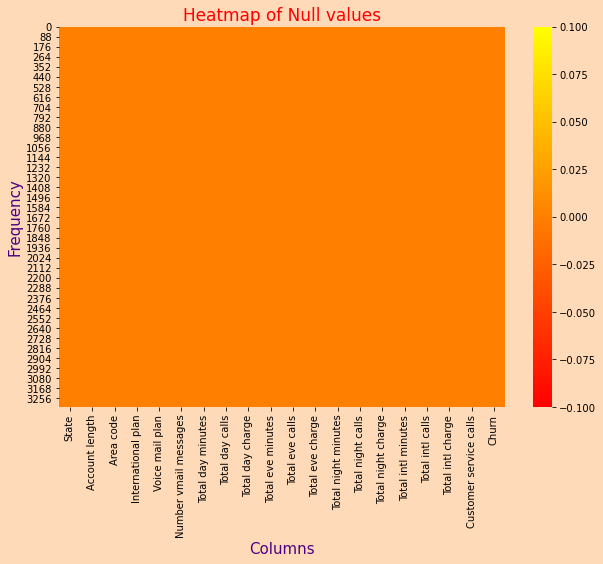

```python
plt.figure(figsize=(10,7),facecolor='peachpuff')
sns.heatmap(d.isnull(),cmap='autumn')
plt.title("Heatmap of Null values",fontsize=17,color='red')
plt.xlabel("Columns",fontsize=15,color='indigo')
plt.ylabel("Frequency",fontsize=15,color='indigo')
plt.show()
```

```python
# Encoding the categorical values
```

```python
le = LabelEncoder()
d['Voice mail plan'] = le.fit_transform(d['Voice mail plan'])
d['International plan'] = le.fit_transform(d['International plan'])
d['Churn'] = le.fit_transform(d['Churn'])
d.head()
```

|  | State | Account length | Area code | International plan | Voice mail plan | Number vmail messages | Total day minutes | Total day calls | Total day charge | Total eve minutes | Total eve calls | Total eve charge | Total night minutes | Total night calls | Total night charge | Total intl minutes | Total intl calls | Total intl charge | Customer service calls | Churn |
| --- | --- | --- | --- | --- | --- | --- | --- | --- | --- | --- | --- | --- | --- | --- | --- | --- | --- | --- | --- | --- |
| 0 | AK | 1 | 408 | 0 | 0 | 0 | 175.2 | 74 | 29.78 | 151.7 | 79 | 12.89 | 230.5 | 109 | 10.37 | 5.3 | 3 | 1.43 | 1 | 0 |
| 1 | AK | 36 | 408 | 0 | 1 | 30 | 146.3 | 128 | 24.87 | 162.5 | 80 | 13.81 | 129.3 | 109 | 5.82 | 14.5 | 6 | 3.92 | 0 | 0 |
| 2 | AK | 41 | 415 | 0 | 0 | 0 | 159.3 | 66 | 27.08 | 125.9 | 75 | 10.70 | 261.9 | 76 | 11.79 | 11.1 | 5 | 3.00 | 1 | 0 |
| 3 | AK | 48 | 415 | 0 | 1 | 37 | 211.7 | 115 | 35.99 | 159.9 | 84 | 13.59 | 144.1 | 80 | 6.48 | 12.2 | 1 | 3.29 | 1 | 0 |
| 4 | AK | 50 | 408 | 0 | 0 | 0 | 183.6 | 107 | 31.21 | 58.6 | 118 | 4.98 | 202.6 | 99 | 9.12 | 8.7 | 3 | 2.35 | 1 | 0 |

```python
# Description of dataset
```

```python
d.describe(include='all')
```

|  | State | Account length | Area code | International plan | Voice mail plan | Number vmail messages | Total day minutes | Total day calls | Total day charge | Total eve minutes | Total eve calls | Total eve charge | Total night minutes | Total night calls | Total night charge | Total intl minutes | Total intl calls | Total intl charge | Customer service calls | Churn |
| --- | --- | --- | --- | --- | --- | --- | --- | --- | --- | --- | --- | --- | --- | --- | --- | --- | --- | --- | --- | --- |
| count | 3333 | 3333.000000 | 3333.000000 | 3333.000000 | 3333.000000 | 3333.000000 | 3333.000000 | 3333.000000 | 3333.000000 | 3333.000000 | 3333.000000 | 3333.000000 | 3333.000000 | 3333.000000 | 3333.000000 | 3333.000000 | 3333.000000 | 3333.000000 | 3333.000000 | 3333.000000 |
| unique | 51 | NaN | NaN | NaN | NaN | NaN | NaN | NaN | NaN | NaN | NaN | NaN | NaN | NaN | NaN | NaN | NaN | NaN | NaN | NaN |
| top | WV | NaN | NaN | NaN | NaN | NaN | NaN | NaN | NaN | NaN | NaN | NaN | NaN | NaN | NaN | NaN | NaN | NaN | NaN | NaN |
| freq | 106 | NaN | NaN | NaN | NaN | NaN | NaN | NaN | NaN | NaN | NaN | NaN | NaN | NaN | NaN | NaN | NaN | NaN | NaN | NaN |
| mean | NaN | 101.064806 | 437.182418 | 0.096910 | 0.276628 | 8.099010 | 179.775098 | 100.435644 | 30.562307 | 200.980348 | 100.114311 | 17.083540 | 200.872037 | 100.107711 | 9.039325 | 10.237294 | 4.479448 | 2.764581 | 1.562856 | 0.144914 |
| std | NaN | 39.822106 | 42.371290 | 0.295879 | 0.447398 | 13.688365 | 54.467389 | 20.069084 | 9.259435 | 50.713844 | 19.922625 | 4.310668 | 50.573847 | 19.568609 | 2.275873 | 2.791840 | 2.461214 | 0.753773 | 1.315491 | 0.352067 |
| min | NaN | 1.000000 | 408.000000 | 0.000000 | 0.000000 | 0.000000 | 0.000000 | 0.000000 | 0.000000 | 0.000000 | 0.000000 | 0.000000 | 23.200000 | 33.000000 | 1.040000 | 0.000000 | 0.000000 | 0.000000 | 0.000000 | 0.000000 |
| 25% | NaN | 74.000000 | 408.000000 | 0.000000 | 0.000000 | 0.000000 | 143.700000 | 87.000000 | 24.430000 | 166.600000 | 87.000000 | 14.160000 | 167.000000 | 87.000000 | 7.520000 | 8.500000 | 3.000000 | 2.300000 | 1.000000 | 0.000000 |
| 50% | NaN | 101.000000 | 415.000000 | 0.000000 | 0.000000 | 0.000000 | 179.400000 | 101.000000 | 30.500000 | 201.400000 | 100.000000 | 17.120000 | 201.200000 | 100.000000 | 9.050000 | 10.300000 | 4.000000 | 2.780000 | 1.000000 | 0.000000 |
| 75% | NaN | 127.000000 | 510.000000 | 0.000000 | 1.000000 | 20.000000 | 216.400000 | 114.000000 | 36.790000 | 235.300000 | 114.000000 | 20.000000 | 235.300000 | 113.000000 | 10.590000 | 12.100000 | 6.000000 | 3.270000 | 2.000000 | 0.000000 |
| max | NaN | 243.000000 | 510.000000 | 1.000000 | 1.000000 | 51.000000 | 350.800000 | 165.000000 | 59.640000 | 363.700000 | 170.000000 | 30.910000 | 395.000000 | 175.000000 | 17.770000 | 20.000000 | 20.000000 | 5.400000 | 9.000000 | 1.000000 |